# Working with Climate Data in R with caladaptR

February 17, 2022  
Andy Lyons

[figure not shown]

# About Me…

[figure not shown]

# Thanks also to …

- Brian Galey
- Lucy Andrews
- Eric Lehmer
- Shruti Mukhtyar
- Nancy Thomas
- Shane Feirer
- Maggi Kelly
- Ben Satzman

[figure not shown]

# About You

## Number of registrants: 58

Type of Organization

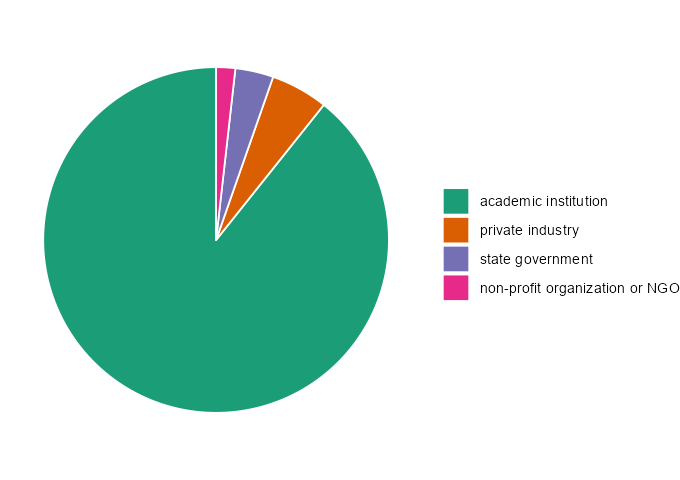

UC Campus

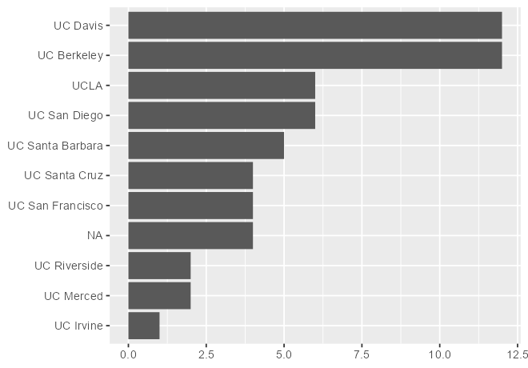

Familiarity with Climate Change Science

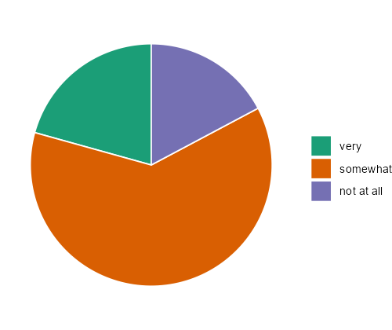

Familiarity with R

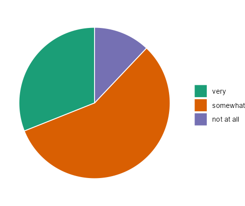

Location

[interactive chart not shown]

# Outcomes

**1) Get familiar with caladaptR**

**2) Hands-on practice with:**

1. importing Cal-Adapt into R via the API
2. data wrangling techniques to prep data for visualization or analysis
3. see techniques for dealing with large volumes of data

**3) Working Code Recipes**

[figure not shown]

+ foundational concepts  
+ code recipes  
+ working examples  
+ practice

**functional pRoficiency!**

# Cal-Adapt

Cal-Adapt is California’s **official portal** for **peer-reviewed** climate data.

Datasets are selected with guidance and priorities from California State agencies.

Modeled Climate Data:

- temperature 6 km
- precipitation 6 km
- snow water equivalent 6 km
- relative humidity 6 km
- surface solar radiation 6 km
- wind speed
- wildfire risk
- drought scenarios
- streamflow
- sea level rise
- other derived variables

See also: [*What climate data does Cal-Adapt provide?*](https://beta.cal-adapt.org/help/get-started/climate-data-and-other-data-on-caladapt/).

Spatial extent of LOCA downscaled climate data layers:

[figure not shown]

# Climate Data

[figure not shown]

# Where are the Data?

[figure not shown]

# Options for Accessing Cal-Adapt Data

| Feature | Cal-Adapt website | Cal-Adapt FTP | caladapt-py | caladaptR |
| --- | --- | --- | --- | --- |
| Download rasters |  |  |  |  |
| Statewide | ✔ | ✔ | ✔ | ✔ |
| User area-of-interest | ✔ |  | ✔ | ✔ |
| 10 recommended GCMs | ✔ | ✔ | ✔ | ✔ |
| All 32 GCMs |  | ✔ | ✔ |  |
| Query features |  |  |  |  |
| Points (user-provided) | ✔ |  | ✔ | ✔ |
| Lines (user-provided) | ✔ |  | ✔ |  |
| Polygons (user-provided) | ✔ |  | ✔ | ✔ |
| Polygons (presets, boundary layers) | ✔ |  |  | ✔ |
| Other |  |  |  |  |
| Extract underlying tables from preset charts | ✔ |  |  |  |

More info:

- [*Accessing Climate Data through Cal-Adapt*](https://www.youtube.com/watch?v=9ox8GPasI9M), Cal-Adapt Quarterly Webinar, June 2019

# Why you might want to work with Cal-Adapt data in R

## Convert statements about climate into actionable info:

*The rolling average of maximum daily temperature will increase by X*

*Species A, B, & C are most likely to survive in the projected climate envelope.*

## Custom visualizations

## Integrate results with other data

- census data
- biodiversity / habitat
- economic data

## Take advantage of other R packages

## Make your own custom models

## Make a decision support tool

[figure not shown]

# caladaptR

[figure not shown]

## Key Features

- `caladaptr` is an **API client** package
- main job is to provide low-level functions for **querying** and **importing** Cal-Adapt data via the API
- uses modern R programming conventions:
- pipe friendly functions
- accepts and returns standard data classes (e.g., tibble, sf, stars)
- units encoded in the results

## Main Uses

- Retrieve values from *any* Cal-Adapt raster series
- Query with **user-provided** points and polygons
- Query built-in **preset** areas-of-interest
- Download climate variables as **tibbles** (data frames) or **rasters** (tiffs & stars)

## Prerequisites

caladaptR users need to know:

- how to **work with data** in R
- what **data** you’re looking for
- how to use climate projections **wisely**

# caladaptR workflow

In general, there are **five** steps to using caladaptR:

[interactive chart not shown]

# Building an API Request

```
cap1 <- ca_loc_pt(coords = c(-121.4687, 38.5938)) %>%
  ca_cvar(c("tasmax", "tasmin")) %>%
  ca_gcm(gcms[1:4]) %>%
  ca_scenario(scenarios[1:2]) %>%
  ca_period("year") %>%
  ca_years(start = 2040, end = 2060)
```

An API Request object consists of between 2 and 4 components:

**1. Location** (*required, pick one*)

| ca_loc_aoipreset() | Query a preset location(s) |
| --- | --- |
| ca_loc_pt() | Question point location(s) |
| ca_loc_sf() | Query simple feature location(s) |

**2. Raster series dataset**

**Option 1**: Choose downscaled climate projection(s) from Scripps using **all 4** of the following constructor functions:

| ca_cvar() | Select the climate variable(s) (i.e., precip, temperature) |
| --- | --- |
| ca_gcm() | Pick or more of the 10 Global Climate Models |
| ca_period() | Select temporal aggregation period (year, month, day) |
| ca_scenario() | Choose your emission scenario(s) |

**Option 2**: Pick *any* of the 830 raster series datasets by their ‘**slug**’:

| ca_slug() | Select a dataset by its slug |
| --- | --- |

**3. Start & end dates** (*optional, pick one*)

| ca_years() | Specify start & end by **year** |
| --- | --- |
| ca_dates() | Specify start & end by **date** |

**4. Options** (*only required for polygons*)

| ca_options() | Spatial aggregation function(s) |
| --- | --- |

# Quick Example

1. Load the package:

```r
library(caladaptr)
```

2. Create an API request object:

```r
cap1 <- ca_loc_pt(coords = c(-121.4687, 38.5938)) %>%  ## specify a location
  ca_cvar(c("tasmax", "tasmin")) %>%                   ## climate variables
  ca_gcm(gcms[1:4]) %>%                                ## GCM(s)
  ca_scenario(scenarios[1:2]) %>%                      ## emission scenarios(s)
  ca_period("year") %>%                                ## temporal aggregation period
  ca_years(start = 2040, end = 2060)                   ## start and end dates
```

3. Check API request

```r
cap1
```

```
## Cal-Adapt API Request
## Location(s):
##   x: -121.469
##   y: 38.594
## Variable(s): tasmax, tasmin
## Temporal aggregration period(s): year
## GCM(s): HadGEM2-ES, CNRM-CM5, CanESM2, MIROC5
## Scenario(s): rcp45, rcp85
## Dates: 2040-01-01 to 2060-12-31
##
```

```r
cap1 %>% ca_preflight()
```

```
## General issues
```

```
##  - none found
```

```
## Issues for querying values
```

```
##  - none found
```

```
## Issues for downloading rasters
```

```
##  - none found
```

```r
plot(cap1, locagrid = TRUE)
```

[interactive chart not shown]

4. Fetch data:

```r
cap1_tbl <- ca_getvals_tbl(cap1, quiet = TRUE)
```

5. View the results

```r
cap1_tbl %>% slice(1:10)
```

| id | cvar | period | gcm | scenario | spag | dt | val |
| --- | --- | --- | --- | --- | --- | --- | --- |
| 1 | tasmax | year | HadGEM2-ES | rcp45 | none | 2040-12-31 | 298.7698 [K] |
| 1 | tasmax | year | HadGEM2-ES | rcp45 | none | 2041-12-31 | 298.7150 [K] |
| 1 | tasmax | year | HadGEM2-ES | rcp45 | none | 2042-12-31 | 298.5987 [K] |
| 1 | tasmax | year | HadGEM2-ES | rcp45 | none | 2043-12-31 | 299.6766 [K] |
| 1 | tasmax | year | HadGEM2-ES | rcp45 | none | 2044-12-31 | 299.5327 [K] |
| 1 | tasmax | year | HadGEM2-ES | rcp45 | none | 2045-12-31 | 298.2451 [K] |
| 1 | tasmax | year | HadGEM2-ES | rcp45 | none | 2046-12-31 | 298.2486 [K] |
| 1 | tasmax | year | HadGEM2-ES | rcp45 | none | 2047-12-31 | 298.7617 [K] |
| 1 | tasmax | year | HadGEM2-ES | rcp45 | none | 2048-12-31 | 299.6294 [K] |
| 1 | tasmax | year | HadGEM2-ES | rcp45 | none | 2049-12-31 | 298.6877 [K] |

# R Notebooks

R Notebooks are written in “R Markdown”, which combines text and R code.

[figure not shown]

**Tips**

Every time you hit saves, it generates a HTML file in the background.

Remember when you’re in a R Notebook, the working directory is *where the Rmd file resides*.

Common error:  
Error creating notebook: path for html_dependency. Path not found: /tmp/RtmpjR1sPw

[figure not shown]

- Knit button → Clear Knitr Cache, or  
- Restart RStudio

# Notebook 1. Getting Started

In Notebook 1, you will:

- Create API requests for i) a point, and ii) a preset area-of-interest (county)
- Wrangle data for plotting
- Plot a time series

**Getting Help**

- Chat window
- Share screen
- Breakout rooms

Notebook 1. Getting Started | solutions

# Other Ways to Specify Location: Preset Areas-of-Interest

The Cal-Adapt API server has 11 preset **areas of interest** (aka boundary layers).

- Census Tracts
- Counties
- Congressional Districts
- Climatic Regions
- Watersheds
- Irrigated Water Management Districts
- 4th Climate Change Assessment Regions
- Electrical Utilities
- WECC Load Areas
- Event Locations
- Places

You can query these features **without passing a spatial object**!

Example:

```r
norcal_cap <- ca_loc_aoipreset(type = "counties",
                         idfld = "fips",
                         idval = c("06105", "06049", "06089", "06015")) %>%
  ca_gcm(gcms[1:4]) %>%
  ca_scenario(scenarios[1:2]) %>%
  ca_period("year") %>%
  ca_years(start = 2040, end = 2060) %>%
  ca_cvar("pr") %>%
  ca_options(spatial_ag = "max")
```

Plot an API request to verify the location:

```r
plot(norcal_cap)
```

[interactive chart not shown]

# Other Ways to Specify Location: User-Defined Polygon

An API request can use a simple feature data frame as the query location (point, polygon, and multipolygon).

Use `sf::st_read()` to import Shapefiles, geojson, KML, geopackage, ESRI geodatabases, etc.

```r
library(sf)
pinnacles_bnd_sf <- st_read("./notebooks/data/pinnacles_bnd.geojson")
pinnacles_bnd_sf
```

| UNIT_NAME | UNIT_TYPE | STATE | REGION | UNIT_CODE | geometry |
| --- | --- | --- | --- | --- | --- |
| Pinnacles National Park | National Park | CA | PW | PINN |  |

Crate an API request:

```r
pin_cap <- ca_loc_sf(loc = pinnacles_bnd_sf, idfld = "UNIT_CODE") %>%
  ca_slug("et_month_MIROC5_rcp45") %>%
  ca_years(start = 2040, end = 2060) %>%
  ca_options(spatial_ag = "mean")

plot(pin_cap, locagrid = TRUE)
```

[interactive chart not shown]

Fetch data:

```r
pin_tbl <- pin_cap %>% ca_getvals_tbl()
head(pin_tbl)
```

| UNIT_CODE | slug | spag | dt | val |
| --- | --- | --- | --- | --- |
| PINN | et_month_MIROC5_rcp45 | mean | 2040-01-31 | 1.20301342 [mm/d] |
| PINN | et_month_MIROC5_rcp45 | mean | 2040-02-29 | 0.83663189 [mm/d] |
| PINN | et_month_MIROC5_rcp45 | mean | 2040-03-31 | 1.49363744 [mm/d] |
| PINN | et_month_MIROC5_rcp45 | mean | 2040-04-30 | 1.56888270 [mm/d] |
| PINN | et_month_MIROC5_rcp45 | mean | 2040-05-31 | 0.58168530 [mm/d] |
| PINN | et_month_MIROC5_rcp45 | mean | 2040-06-30 | 0.01275226 [mm/d] |

# Using Climate Data *Wisely*

*Which weekend in February 2070 has the least chance of rain for my retirement party at the San Luis Obispo Country Club?*

Wise or unwise?

[figure not shown]

**Make this plot**

```
library(caladaptr)
library(dplyr)
library(ggplot2)
library(units)

slo_cap <- ca_loc_pt(coords = c(-120.6276, 35.2130)) %>%
  ca_cvar("pr") %>%
  ca_gcm(gcms[1:4]) %>%
  ca_scenario("rcp45") %>%
  ca_period("day") %>%
  ca_dates(start = "2070-02-01", end = "2070-02-28")

slo_mmday_tbl <- slo_cap %>%
  ca_getvals_tbl(quiet = TRUE) %>%
  mutate(pr_mmday = set_units(as.numeric(val) * 86400, mm/day))

feb2070_weekends_df <- data.frame(dt = as.Date("2070-02-01") + c(0,1,7,8,14,15,21,22), y = 50)

ggplot(data = slo_mmday_tbl, aes(x = as.Date(dt), y = as.numeric(pr_mmday))) +
  geom_col(data = feb2070_weekends_df, aes(x = dt, y = y), fill = "red", alpha = 0.2) +
  geom_point(aes(color=gcm)) +
  labs(title = "Chance of Rain at the San Luis Obispo Country Club, February 2070",
       subtitle = "Pink bars represent the weekends. Emissions scenario: RCP 4.5.",
       x = "date", y = "mm") +
  theme(plot.caption = element_text(hjust = 0))
```

## 1) Examine 20-30 Year Time Periods

By definition, climate is weather averaged over **30+ years**.

Climate models are designed to capture *trends* in *climate*.

⇒ If you’re not averaging at least 20-30 years of data, you’re probably doing something wrong.

## 2) Look at multiple models & emissions scenarios

There is variability among models.

The biggest source of uncertainty (by far) is the future of emissions.

## 3) Aggregate, aggregate, aggregate

- don’t look at specific points in space or time
- average years together
- average models together
- take rolling averages
- interested in an area? spatially aggregate

## 4) Look at both central tendency and the range of variability

Both are important.

Variability can be within and/or between models.

[figure not shown]

## 4) Compare, compare, compare

- Compare projected future against historical conditions
- Compare Place A vs Place B
- Compare emission scenarios
- Compare models

Climate analogue: *Where can I go right now to see the climate that my city will face in 50 years?*

How should we compare the past to the future?

**Observed historic record and modeled future** - *different animals*

[figure not shown]

**Model historic climate and modeled future** - *comparable*

[figure not shown]

# Raster Series Catalog

`caladaptR` comes with a Raster Series Catalog

For each raster series the catalog will list its:

- full name
- slug (unique identifier)
- begin and end date
- temporal resolution
- units
- extent
- number of rasters

The catalog can be retrieved using `ca_catalog_rs()` (returns a tibble).

The best way to browse the catalog is with RStudio’s View pane. You can then use the filter buttons to find the raster series you want.

```r
View(ca_catalog_rs())
```

# Data Wrangling

Cal-Adapt data always comes down in a “long” format:

```r
head(cap1_tbl)
```

| id | cvar | period | gcm | scenario | spag | dt | val |
| --- | --- | --- | --- | --- | --- | --- | --- |
| 1 | tasmax | year | HadGEM2-ES | rcp45 | none | 2040-12-31 | 298.7698 [K] |
| 1 | tasmax | year | HadGEM2-ES | rcp45 | none | 2041-12-31 | 298.7150 [K] |
| 1 | tasmax | year | HadGEM2-ES | rcp45 | none | 2042-12-31 | 298.5987 [K] |
| 1 | tasmax | year | HadGEM2-ES | rcp45 | none | 2043-12-31 | 299.6766 [K] |
| 1 | tasmax | year | HadGEM2-ES | rcp45 | none | 2044-12-31 | 299.5327 [K] |
| 1 | tasmax | year | HadGEM2-ES | rcp45 | none | 2045-12-31 | 298.2451 [K] |

To make useful plots, maps, and summaries, you often have to ‘munge’ or ‘wrangle’ the data, which may include:

- selecting columns
- filtering rows
- changing column data type
- calculating new columns
- grouping rows; summarizing
- reshaping long to wide (aka pivoting)

Fortunately you have a very robust toolbox:

| [cheatsheet](https://github.com/rstudio/cheatsheets/blob/master/data-transformation.pdf) | [cheatsheet](https://github.com/rstudio/cheatsheets/blob/master/data-import.pdf) | [cheatsheet](https://github.com/rstudio/cheatsheets/blob/master/sf.pdf) | [cheatsheet](https://rstudio.com/wp-content/uploads/2016/11/ggplot2-cheatsheet-2.1.pdf) |
| --- | --- | --- | --- |

Useful functions

- filter()
- select()
- mutate()
- group_by()
- summarise()
- left_join()
- pivot_wider()

**Qtn.** How do I know what data wrangling is needed?

**Ans.** Work backward from your analysis or visualization functions.

# Notebook 2. Find and Wrangle Data

In Notebook 2, you will:

- explore the Cal-Adapt data catalog
- retrieve data using a slug
- wrangle data for visualization and analysis
- make histograms to visualize trends in variability

Notebook 2. Finding Data | solutions

# Shiny Apps

[figure not shown]

- The Shiny package allows you to create browser-based apps that run R in the background.
- You need to know to R, but you don’t need to know JavaScript, HTML, CSS, network protocols, etc.
- Can run them locally or online

[figure not shown]

Examples:

- [Plot Annual Time Series](https://caladaptr.shinyapps.io/timeseries/) (online)
- [Projected Chill Portions](https://ucanr-igis.shinyapps.io/chill/) (online)
- See samples in the [caladaptr.apps](https://github.com/ucanr-igis/caladaptr.apps/) package

```
library(caladaptr.apps)

## Launch the time series app
ca_launch("timeseries")

## Launch the projected chill portions app
ca_launch("chill")
```

# Notebook 3. Shiny Apps

In Notebook 3, you will:

- launch a Shiny app using the `caladaptr.apps` package
- explore the anatomy of a simple Shiny app

Notebook 3. Shiny Apps

# Additional Resources

## https://ucanr-igis.github.io/caladaptr/

- documentation
- Articles (tutorials and technical guides)
- R notebooks
- presentations

## Work in progress…

- e-book of code recipes
- [Degree Day](https://ucanr-igis.github.io/degday/) R package
- CA weather APIs
- Shiny apps

## Test Cases and Developers Wanted!

- use-cases ⇒ code recipes and Shiny apps
- beta testers
- developers